# tour_9.28

### [대회명]

- 국문관광정보(POI) 카테고리 자동 분류 경진대회

### [배경]

- 최신 핫플레이스를 소개하는 디지털 여행정보서비스가 개발되고 있으며, 관광지점 정보(POI:Point Of Interests)데이터의 가치가 더욱 높아지고 있습니다.
- 한국관광공사가 제공하는 국문관광정보의 생산을 인공지능의 힘으로 자동화 한다면, 더 적은 공공의 예산으로 더 많은 POI 데이터가 만들어질 수 있습니다.
- 관광지에 관한 텍스트와 이미지 데이터를 이용하여 카테고리를 자동분류할수 있는 최적의 알고리즘을 만들어 주세요

### [주제]

- 국문관광정보(POI)의 텍스트와 이미지데이터를 이용한 카테고리 자동분류 AI솔루션 개발

### [설명]

- 데이터로 주어지는 2만 3천여개의 POI를 사용하여 관광지 카테고리 (대>중>소) 중 '소' 카테고리를 예측
- '소'카테고리에 항구/포구, 골프, 한식, 서양식, 바/까페, 야영장,오토캠핑장, 사찰, 박물관, 다리/대교, 해수욕장, 유원지 등등

# Import

```python
import random
import pandas as pd
import numpy as np
import os
import cv2
from tqdm.auto import tqdm # 진행바
import warnings
warnings.filterwarnings(action='ignore')

# sklearn
from sklearn import preprocessing
from sklearn.feature_extraction.text import CountVectorizer
from sklearn.model_selection import train_test_split
from sklearn.metrics import f1_score, accuracy_score
from sklearn.metrics import classification_report

# torch
import torch
import torch.nn as nn
import torch.optim as optim
import torch.nn.functional as F
from torch.utils.data import Dataset, DataLoader
import albumentations as A # fast image agumentation library by_ha
from albumentations.pytorch.transforms import ToTensorV2 # 이미지 형 변환 by_ha
import torchvision.models as models
device = torch.device('cuda') if torch.cuda.is_available() else torch.device('cpu')
# gpu 사용하기 위한 코드_ha
# cuda가 설치되어 있으면 gpu_ha
from IPython.display import Image
```

# 데이터 형식

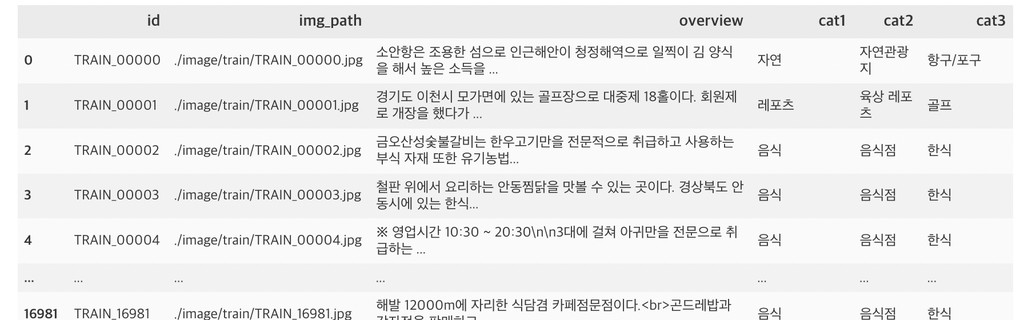

```python
Image("./dataset.png")
```

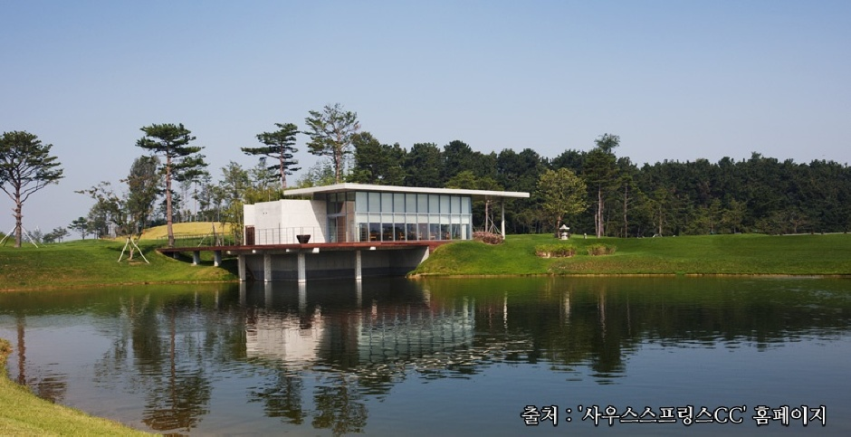

```python
Image("./image/train/TRAIN_00001.jpg")
```

# Hyperparameter Setting

```python
CFG = {
    'IMG_SIZE':128,
    'EPOCHS':10,
    'LEARNING_RATE':3e-4, # 3 x 10^-4 가장 잘됨
    'BATCH_SIZE':96, # 32의 배수
    'SEED':41
}
# 이미지 사이즈, 이폭, 학습률, 배치사이즈, 시드 고정 by_ha
# ---CFG변수에 키값(IMG_SIZE, EPOCHS, LEARNING_RATE, BATCH_SIZE, SEED)과
# 수치형태의 밸류값으로 딕셔너리를 만들어 저장---
```

# Fixed RandomSeed

```python
def seed_everything(seed):
    random.seed(seed)
    os.environ['PYTHONHASHSEED'] = str(seed)
    np.random.seed(seed)
    torch.manual_seed(seed)
    torch.cuda.manual_seed(seed)
    torch.backends.cudnn.deterministic = True
    torch.backends.cudnn.benchmark = True

seed_everything(CFG['SEED']) # Seed 고정
```

# Data Load & Train/Validation Split

```python
# train데이터 로드
all_df = pd.read_csv('./train_tour.csv')
```

```python
all_df
```

|  | id | img_path | overview | cat1 | cat2 | cat3 |
| --- | --- | --- | --- | --- | --- | --- |
| 0 | TRAIN_00000 | ./image/train/TRAIN_00000.jpg | 소안항은 조용한 섬으로 인근해안이 청정해역으로 일찍이 김 양식을 해서 높은 소득을 ... | 자연 | 자연관광지 | 항구/포구 |
| 1 | TRAIN_00001 | ./image/train/TRAIN_00001.jpg | 경기도 이천시 모가면에 있는 골프장으로 대중제 18홀이다. 회원제로 개장을 했다가 ... | 레포츠 | 육상 레포츠 | 골프 |
| 2 | TRAIN_00002 | ./image/train/TRAIN_00002.jpg | 금오산성숯불갈비는 한우고기만을 전문적으로 취급하고 사용하는 부식 자재 또한 유기농법... | 음식 | 음식점 | 한식 |
| 3 | TRAIN_00003 | ./image/train/TRAIN_00003.jpg | 철판 위에서 요리하는 안동찜닭을 맛볼 수 있는 곳이다. 경상북도 안동시에 있는 한식... | 음식 | 음식점 | 한식 |
| 4 | TRAIN_00004 | ./image/train/TRAIN_00004.jpg | ※ 영업시간 10:30 ~ 20:30\n\n3대에 걸쳐 아귀만을 전문으로 취급하는 ... | 음식 | 음식점 | 한식 |
| ... | ... | ... | ... | ... | ... | ... |
| 16981 | TRAIN_16981 | ./image/train/TRAIN_16981.jpg | 해발 12000m에 자리한 식담겸 카페점문점이다.<br>곤드레밥과 감자전을 판매하고... | 음식 | 음식점 | 한식 |
| 16982 | TRAIN_16982 | ./image/train/TRAIN_16982.jpg | 설악힐호텔은 동해고속도로 속초톨게이트에서 멀지 않은 관광로 변에 있다. 속초의 대표... | 숙박 | 숙박시설 | 모텔 |
| 16983 | TRAIN_16983 | ./image/train/TRAIN_16983.jpg | 충남 서산시 중심가에 위치한 줌모텔은 프라이버스가 보장되는 조용한 공간으로 가치가 ... | 숙박 | 숙박시설 | 모텔 |
| 16984 | TRAIN_16984 | ./image/train/TRAIN_16984.jpg | 토토큰바위캠핑장은 경기도 가평지역 내에서도 청정지역으로 손꼽히는 지역으로 주변에 화... | 레포츠 | 육상 레포츠 | 야영장,오토캠핑장 |
| 16985 | TRAIN_16985 | ./image/train/TRAIN_16985.jpg | 포천의 진산으로 불리우는 왕방산(王訪山)에는 천년의 역사를 간직하고 있는 왕산사(王... | 인문(문화/예술/역사) | 역사관광지 | 사찰 |

16986 rows × 6 columns

```python
# 트레인 데이터, 검증 데이터 분할
train_df, val_df, _, _ = train_test_split(all_df, all_df['cat3'], test_size=0.2, random_state=CFG['SEED'])
# train set, validation set 구별 by_ha
```

```python
train_df
```

|  | id | img_path | overview | cat1 | cat2 | cat3 |
| --- | --- | --- | --- | --- | --- | --- |
| 1786 | TRAIN_01786 | ./image/train/TRAIN_01786.jpg | 함평양서파충류생태공원은 전남 함평군 신광면에 자리 잡고 있다. 공원 내에는 양서류를... | 인문(문화/예술/역사) | 문화시설 | 박물관 |
| 16670 | TRAIN_16670 | ./image/train/TRAIN_16670.jpg | 국제수변레포츠 단지 내 위치한 충주 탄금호 캠핑 리조트는 다양한 문화체험이 가능한 ... | 레포츠 | 육상 레포츠 | 야영장,오토캠핑장 |
| 3377 | TRAIN_03377 | ./image/train/TRAIN_03377.jpg | 경남 함양군 서하면에 위치한 함양 라온캠핑장은 마운틴뷰의 조용하고 깨끗한 신설 캠핑... | 레포츠 | 육상 레포츠 | 야영장,오토캠핑장 |
| 12814 | TRAIN_12814 | ./image/train/TRAIN_12814.jpg | 캠프바베큐는 충남 천안시 동남구에 자리 잡고 있다. 천안시청을 기점으로 약 8㎞가량... | 레포츠 | 육상 레포츠 | 야영장,오토캠핑장 |
| 2607 | TRAIN_02607 | ./image/train/TRAIN_02607.jpg | 원수산습지생태원은 세종시 연기면 세종리에 있다. 생태원 내에는 보존습지, 수생식물습... | 자연 | 자연관광지 | 자연생태관광지 |
| ... | ... | ... | ... | ... | ... | ... |
| 6819 | TRAIN_06819 | ./image/train/TRAIN_06819.jpg | 밤바다의 멋진 야경을 보며 걷는 물 위의 데크 산책로, 바다 위에 조성된 742m의... | 인문(문화/예술/역사) | 건축/조형물 | 다리/대교 |
| 15829 | TRAIN_15829 | ./image/train/TRAIN_15829.jpg | 남해비치텔은 한려해상 국립공원의 중심지역인 남해군 설천면 노량리에 위치해 있다. 이... | 숙박 | 숙박시설 | 모텔 |
| 8513 | TRAIN_08513 | ./image/train/TRAIN_08513.jpg | 장경리해변은 자갈모래로 형성된 해변을 가지고 있으며 백사장의 길이는 1.5km 정도... | 자연 | 자연관광지 | 해수욕장 |
| 931 | TRAIN_00931 | ./image/train/TRAIN_00931.jpg | 서울 종로에 자리한 낙원떡집은 ‘서울미래유산’으로도 선정될 만큼 오랜 역사와 전통을... | 음식 | 음식점 | 한식 |
| 1984 | TRAIN_01984 | ./image/train/TRAIN_01984.jpg | 전통적인 조리법대로 차려지는 진지상은 죽과 물김치를 시작으로 구절판과 탕평채, 해파... | 음식 | 음식점 | 한식 |

13588 rows × 6 columns

```python
val_df
```

|  | id | img_path | overview | cat1 | cat2 | cat3 |
| --- | --- | --- | --- | --- | --- | --- |
| 15950 | TRAIN_15950 | ./image/train/TRAIN_15950.jpg | 미생의 다리의 '미생'은 시흥시의 슬로건인 '미래를 키우는 생명도시'의 줄임말로, ... | 인문(문화/예술/역사) | 건축/조형물 | 다리/대교 |
| 2645 | TRAIN_02645 | ./image/train/TRAIN_02645.jpg | 전남 내륙 한가운데에 위치한 화순은 조광조가 그의 이상을 펼치지 못하고 유배되어 죽... | 인문(문화/예술/역사) | 휴양관광지 | 유원지 |
| 11605 | TRAIN_11605 | ./image/train/TRAIN_11605.jpg | 목포해상W쇼는 가족의 시선에서 바라본 아름다운 목포의 이야기를 '목포의 눈물'을 비... | 인문(문화/예술/역사) | 공연/행사 | 기타행사 |
| 14508 | TRAIN_14508 | ./image/train/TRAIN_14508.jpg | 인천 월미도에 위치한 호텔 월미여관은 2019년 10월에 개관한 ‘신상’이다. 개화... | 숙박 | 숙박시설 | 한옥스테이 |
| 1368 | TRAIN_01368 | ./image/train/TRAIN_01368.jpg | 세종 10년(1428년)에 군수 하담이 건립하였다고 전하며 일설에는 소헌왕후의 8왕... | 인문(문화/예술/역사) | 역사관광지 | 유적지/사적지 |
| ... | ... | ... | ... | ... | ... | ... |
| 1730 | TRAIN_01730 | ./image/train/TRAIN_01730.jpg | 진주를 관통하는 남강은 강변을 따라 길게 펼쳐진 산책길과 자전거길로 사람들의 발길을... | 인문(문화/예술/역사) | 휴양관광지 | 공원 |
| 2057 | TRAIN_02057 | ./image/train/TRAIN_02057.jpg | 현등산(운악산)은 해발 934.7m의 기암과 봉으로 이루어져 있으며, 산세가 아름다... | 자연 | 자연관광지 | 자연휴양림 |
| 8574 | TRAIN_08574 | ./image/train/TRAIN_08574.jpg | 강남역과 통로가 연결되어 있는 아이해브어드림은 레스토랑이면서 자체 공연장이 마련되어... | 음식 | 음식점 | 서양식 |
| 1500 | TRAIN_01500 | ./image/train/TRAIN_01500.jpg | 동탄 리베라cc와 방아다리 공원 인근 신리천 카페거리에 있다. 동탄 신리천을 정원... | 음식 | 음식점 | 바/까페 |
| 16084 | TRAIN_16084 | ./image/train/TRAIN_16084.jpg | 김천시 증산면에서 성주댐을 지나 고령 방면으로 이어지는 대가천계곡. 이 계곡은 한강... | 자연 | 자연관광지 | 계곡 |

3398 rows × 6 columns

# Label-Encoding

```python
# 라벨인코더 로드 및 시리즈(train_df['cat3'])의 값들을 배열로 추출해 라벨인코더에 훈련
le = preprocessing.LabelEncoder()
le.fit(train_df['cat3'].values)
# 카테고리형 데이터를 수치형으로 변환하는 labelencoder by_ha
```

```
LabelEncoder()
```

```python
# train_df['cat3'].values 어레이를 라벨인코딩
train_df['cat3'] = le.transform(train_df['cat3'].values)
val_df['cat3'] = le.transform(val_df['cat3'].values)
```

```python
# cat3에 labelencoder를 적용하기
```

# Vectorizer

```python
vectorizer = CountVectorizer(max_features=4096)
# overview를 vectorize하는 vectorizer 선언, 최대 특성 수는 4096 by_ha
# max_features 2의 배수
```

```python
train_vectors = vectorizer.fit_transform(train_df['overview'])
```

```python
train_vectors
```

```
<13588x4096 sparse matrix of type '<class 'numpy.int64'>'
	with 425431 stored elements in Compressed Sparse Row format>
```

```python
train_vectors = train_vectors.todense() # 매트릭스 화
```

```python
train_vectors
```

```
matrix([[0, 0, 0, ..., 0, 0, 0],
        [0, 0, 0, ..., 0, 0, 0],
        [0, 0, 0, ..., 0, 0, 0],
        ...,
        [0, 0, 0, ..., 0, 0, 0],
        [0, 0, 0, ..., 0, 0, 0],
        [0, 0, 0, ..., 0, 0, 0]])
```

```python
val_vectors = vectorizer.transform(val_df['overview'])
val_vectors
```

```
<3398x4096 sparse matrix of type '<class 'numpy.int64'>'
	with 106061 stored elements in Compressed Sparse Row format>
```

```python
val_vectors = val_vectors.todense()
val_vectors
```

```
matrix([[0, 0, 0, ..., 0, 0, 0],
        [0, 0, 0, ..., 0, 0, 0],
        [0, 0, 0, ..., 0, 0, 0],
        ...,
        [0, 0, 0, ..., 0, 0, 0],
        [1, 0, 0, ..., 0, 0, 0],
        [0, 0, 0, ..., 0, 0, 0]])
```

```python
train_vectors.shape
```

```
(13588, 4096)
```

```python
val_vectors.shape
```

```
(3398, 4096)
```

# CustomDataset

### 데이터셋 생성

##### (1). **init** (2). **getitem** (3).**len**함수를 꼭 넣어야함

##### **init** 함수는 Dataset 객체가 생성될 때 한 번만 실행됨

##### **len** 함수는 데이터셋의 샘플 개수를 반환함

##### **getitem** 함수는 주어진 인덱스 idx 에 해당하는 샘플을 데이터셋에서 불러오고 반환함

```python
# Dataset 생성_ha
class CustomDataset(Dataset):
    def __init__(self, img_path_list, text_vectors, label_list, transforms, infer=False):
        self.img_path_list = img_path_list
        self.text_vectors = text_vectors
        self.label_list = label_list
        self.transforms = transforms
        self.infer = infer

    def __getitem__(self, index):
        # NLP
        text_vector = self.text_vectors[index]

        # Image
        img_path = self.img_path_list[index]
        image = cv2.imread(img_path)

        if self.transforms is not None:
            image = self.transforms(image=image)['image']

        # Label
        if self.infer:  # infer == True, test_data로부터 label "결과 추출" 시 사용 by_ha
            return image, torch.Tensor(text_vector).view(-1)
        else: # # infer == False_ha
            label = self.label_list[index] # dataframe에서 label 가져와 "학습" 시 사용 by_ha
            return image, torch.Tensor(text_vector).view(-1), label

    def __len__(self):
        return len(self.img_path_list)
```

## train_transform 변수에 A.Compose 대입

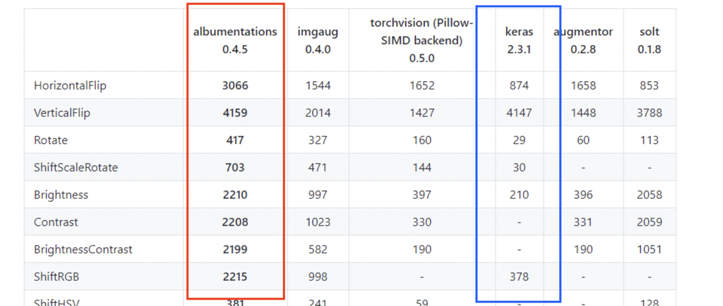

```python
Image("./albumentations.png")
```

## ImageNet의 validation set 2000장에 대해 Intel CPU로 test한 결과이며 표의 값은 single core에서 초당 처리되는 image의 수를 나타내고 있음. 거의 모든 transform에서 많게는 2배 이상 빠른 처리 속도를 보여주고 있음.

##### *출처: https://hoya012.github.io/blog/albumentation_tutorial/*

```python
train_transform = A.Compose([
                            A.Resize(CFG['IMG_SIZE'],CFG['IMG_SIZE']),
                            # 128*128size로 resize
                            A.Normalize(mean=(0.485, 0.456, 0.406),
                                        std=(0.229, 0.224, 0.225),
                                        max_pixel_value=255.0,
                                        p=1.0),
                            ToTensorV2()
                            ])
```

### test_transform 변수에 A.Compose 대입

```python
test_transform = A.Compose([
                            A.Resize(CFG['IMG_SIZE'],CFG['IMG_SIZE']),
                            A.Normalize(mean=(0.485, 0.456, 0.406),
                                        std=(0.229, 0.224, 0.225),
                                        max_pixel_value=255.0,
                                        p=1.0),
                            ToTensorV2()
                            ])
```

- albumentations -> fast image augmentation library
- albumentations.Compose -> transform = A.Compose([])을 이용하여 이미지와 라벨 각각에 Augmentation을 적용하기 위한 객체를 생성
- albumentations.Resize(128, 128) -> 128*128 size로 resize
- albumentations.Normalize() -> 입력 받은 이미지 값의 범위를 (0, 255) → (-1, 1) 범위로 줄여주는 역할, 위에서는 평균값, 분산값, 최대 픽셀값으로 img = (img - mean *max_pixel_value) / (std* max_pixel_value)을 계산.
- ToTensorV2 -> tensor형 변환

##### DataLoader는 일반적으로 샘플들을 미니배치(minibatch)로 전달하고, 매 에폭(epoch)마다 데이터를 다시 섞어서 과적합(overfit)을 방지하고 python의 multiprocessing(CPU_WORKER)을 사용하여 데이터 검색 속도를 높이려고 함

```python
# __init__(self, img_path_list, text_vectors, label_list, transforms, infer=False) by_ha
train_dataset = CustomDataset(train_df['img_path'].values, train_vectors, train_df['cat3'].values, train_transform)
train_dataset
```

```
<__main__.CustomDataset at 0x2d2853460>
```

```python
train_loader = DataLoader(train_dataset, batch_size = CFG['BATCH_SIZE'], num_workers=0)
train_loader
```

```
<torch.utils.data.dataloader.DataLoader at 0x2d28531c0>
```

```python
val_dataset = CustomDataset(val_df['img_path'].values, val_vectors, val_df['cat3'].values, test_transform)
val_dataset
```

```
<__main__.CustomDataset at 0x17919fc70>
```

```python
val_loader = DataLoader(val_dataset, batch_size=CFG['BATCH_SIZE'], num_workers=0)
val_loader
```

```
<torch.utils.data.dataloader.DataLoader at 0x17919fa60>
```

- DataLoader: Dataset와 Sampler를 결합하고 지정된 데이터 세트에 대해 반복 가능한 기능을 제공.
  - dataset (Dataset): 데이터를 로드할 데이터 집합.
  - batch_size (int, optional): how many samples per batch to load (default: 1).
  - num_workers (int, optional): how many subprocesses to use for data loading. 0 means that the data will be loaded in the main process. (default: 0) -> 6으로 설정 시 안돌아감([Errno 32] Broken pipe). 0으로 변경해야 됨

# Model Define

```python
class CustomModel(nn.Module):
    def __init__(self, num_classes=len(le.classes_)):
        super(CustomModel, self).__init__()
        # Image
        self.cnn_extract = nn.Sequential(
            nn.Conv2d(3, 8, kernel_size=3, stride=1, padding=1),
            # input_channel = 3 : RGB 3개의 채널이기 때문 by_ha
            # out_channel = 8 : 출력하는 채널 8개 by_ha
            # stride = 1 : stride 만큼 이미지 이동하면서 cnn 수행 by_ha
            # padding = 1 : zero-padding할 사이즈 by_ha
            nn.ReLU(),  # 사용할 활성화 함수: Relu를 사용 by_ha
            nn.MaxPool2d(kernel_size=2, stride=2), # 최댓값을 뽑아내는 맥스 풀링 by_ha
            nn.Conv2d(8, 16, kernel_size=3, stride=1, padding=1),
            nn.ReLU(),
            nn.MaxPool2d(kernel_size=2, stride=2),
            nn.Conv2d(16, 32, kernel_size=3, stride=1, padding=1),
            nn.ReLU(),
            nn.MaxPool2d(kernel_size=2, stride=2),
            nn.Conv2d(32, 64, kernel_size=4, stride=1, padding=1),
            nn.ReLU(),
            nn.MaxPool2d(kernel_size=2, stride=2)
        )
        # Text
        self.nlp_extract = nn.Sequential(
            nn.Linear(4096, 2048), # 선형회귀. 4096개의 입력으로 2048개의 출력 by_ha
#            nn.GRU(2048, 128),
            nn.ReLU(),
            nn.Linear(2048, 1024), # 선형회귀. 2048개의 입력으로 1024개의 출력 by_ha
        )
        # Classifier
        self.classifier = nn.Sequential(
            nn.Linear(4160, num_classes)
            # 선형회귀. 4160개의 입력으로 num_classes, 즉 cat3의 종류 개수만큼의 출력 by_ha
            # 근데 왜 4160개? "4160 - 1024 = 3136"이고 "3136 / 64 = 49". 즉 이미지는 "7*7*64"로 출력됨. by_ha
        )


    def forward(self, img, text):
        img_feature = self.cnn_extract(img) # cnn_extract 적용 by_ha
        img_feature = torch.flatten(img_feature, start_dim=1) # 1차원으로 변환 by_ha
        text_feature = self.nlp_extract(text) # nlp_extract 적용 by_ha
        feature = torch.cat([img_feature, text_feature], axis=1) # 2개 연결(3136 + 1024) by_ha
        output = self.classifier(feature) # classifier 적용 by_ha
        return output
```

결론:

- Image: conv -> ReLU -> MaxPooling -> conv -> relu -> maxpooling -> conv -> relu -> maxpooling -> conv -> relu -> maxpooling
- Text: linear -> relu -> linear
- classifier : linear

# Train

```python
def train(model, optimizer, train_loader, val_loader, scheduler, device):
    model.to(device) # gpu(cpu)에 적용 by_ha

    criterion = nn.CrossEntropyLoss().to(device) # CrossEntropyLoss: 다중분류를 위한 손실함수 by_ha
    best_score = 0
    best_model = None# 최고의 모델을 추출하기 위한 파라미터 by_ha

    for epoch in range(1,CFG["EPOCHS"]+1):
        model.train()# 학습시킴._ha
        train_loss = []
        for img, text, label in tqdm(iter(train_loader)):# train_loader에서 img, text, label 가져옴 by_ha
            img = img.float().to(device)
            text = text.to(device)
            #label = label.type(torch.LongTensor)
            # label type을 LongTensor로 형변환, 추가하여 에러 해결 ?? by_ha
            label = label.to(device)

            optimizer.zero_grad() # 이전 루프에서 .grad에 저장된 값이 다음 루프의 업데이트에도 간섭하는 걸 방지, 0으로 초기화 by_ha

            model_pred = model(img, text)# 예측 by_ha

            loss = criterion(model_pred, label)# 예측값과 실제값과의 손실 계산 by_ha

            loss.backward()# .backward() 를 호출하면 역전파가 시작(loss에 backward가 있었구나_mine) by_ha
            optimizer.step()# optimizer.step()을 호출하여 역전파 단계에서 수집된 변화도로 매개변수를 조정 by_ha

            train_loss.append(loss.item())
        # 모든 train_loss 가져옴_ha
        tr_loss = np.mean(train_loss)

        val_loss, val_score = validation(model, criterion, val_loader, device)
        # 검증 시작, 여기서 validation 함수 사용 by_ha

        print(f'Epoch [{epoch}], Train Loss : [{tr_loss:.5f}] Val Loss : [{val_loss:.5f}] Val Score : [{val_score:.5f}]')

        if scheduler is not None:
            scheduler.step()
            # scheduler의 의미: Learning Rate Scheduler => learning rate를 조절한다. by_ha
            # DACON에서는 CosineAnnealingLR 또는 CosineAnnealingWarmRestarts 를 주로 사용한다. by_ha
        if best_score < val_score:# 최고의 val_score을 가진 모델에 대해서만 최종적용을 시킴 by_ha
            best_score = val_score
            best_model = model

    return best_model# val_score가 가장 높은 모델을 출력 by_ha
```

# loss 출력함수

## F1 Score : 정밀도와 재현율의 조화 평균

## 모델이 얼마나 잘 작동하는 척도 3가지

### 정확도(Accuracy) : 예측이 정답과 얼마나 정확한가?(단점: 눈내리는날 예측 예: false인 경우)

### 재현율(Recall) : 찾아야 할 것중에 실제로 찾은 비율은? recall은 모델이 눈이 내릴거라 예측한 날의 수를 실제로 눈이 내린 날의 수로 나눈 값

### 정밀도(Precision) : 예측한 것중에 정답의 비율은?, 실제로 눈이 내린 날의 수를 모델이 눈이 내릴거라 예측한 날의 수로 나눈 값

##### *출처: https://bhcboy100.medium.com/%EB%A8%B8%EC%8B%A0%EB%9F%AC%EB%8B%9D-%EB%B6%84%EB%A5%98-%ED%8F%89%EA%B0%80%EC%A7%80%ED%91%9C-%EC%9D%B4%ED%95%B4%ED%95%98%EA%B8%B0-%EC%A0%95%ED%99%95%EB%8F%84-%EC%A0%95%EB%B0%80%EB%8F%84-%EC%9E%AC%ED%98%84%EC%9C%A8-f1-%EC%8A%A4%EC%BD%94%EC%96%B4-6bf91535a01a*

```python
# loss 출력함수
def score_function(real, pred):
    return f1_score(real, pred, average="weighted")

# 검증함수(train의 일부)
def validation(model, criterion, val_loader, device):
    model.eval()# nn.Module에서 train time과 eval time에서 수행하는 다른 작업을 수행할 수 있도록 switching 하는 함수 by_ha

    model_preds = []# 예측값 by_ha
    true_labels = []# 실제값 by_ha

    val_loss = []

    with torch.no_grad():
        for img, text, label in tqdm(iter(val_loader)):# val_loader에서 img, text, label 가져옴 by_ha
            img = img.float().to(device)
            text = text.to(device)
            #label = label.type(torch.LongTensor)  # label type을 LongTensor로 형변환, 추가하여 에러 해결 by_ha
            label = label.to(device)

            model_pred = model(img, text)

            loss = criterion(model_pred, label) # 예측값, 실제값으로 손실함수 적용 -> loss 추출 by_ha

            val_loss.append(loss.item())# loss 출력, val_loss에 저장 by_ha

            model_preds += model_pred.argmax(1).detach().cpu().numpy().tolist()
            true_labels += label.detach().cpu().numpy().tolist()

    test_weighted_f1 = score_function(true_labels, model_preds)# loss 출력, val_loss에 저장 by_ha
    return np.mean(val_loss), test_weighted_f1 # 각각 val_loss, val_score에 적용됨 by_ha
```

# Run!!

```python
model = CustomModel()
model.eval()
```

```
CustomModel(
  (cnn_extract): Sequential(
    (0): Conv2d(3, 8, kernel_size=(3, 3), stride=(1, 1), padding=(1, 1))
    (1): ReLU()
    (2): MaxPool2d(kernel_size=2, stride=2, padding=0, dilation=1, ceil_mode=False)
    (3): Conv2d(8, 16, kernel_size=(3, 3), stride=(1, 1), padding=(1, 1))
    (4): ReLU()
    (5): MaxPool2d(kernel_size=2, stride=2, padding=0, dilation=1, ceil_mode=False)
    (6): Conv2d(16, 32, kernel_size=(3, 3), stride=(1, 1), padding=(1, 1))
    (7): ReLU()
    (8): MaxPool2d(kernel_size=2, stride=2, padding=0, dilation=1, ceil_mode=False)
    (9): Conv2d(32, 64, kernel_size=(4, 4), stride=(1, 1), padding=(1, 1))
    (10): ReLU()
    (11): MaxPool2d(kernel_size=2, stride=2, padding=0, dilation=1, ceil_mode=False)
  )
  (nlp_extract): Sequential(
    (0): Linear(in_features=4096, out_features=2048, bias=True)
    (1): ReLU()
    (2): Linear(in_features=2048, out_features=1024, bias=True)
  )
  (classifier): Sequential(
    (0): Linear(in_features=4160, out_features=128, bias=True)
  )
)
```

# (scheduler)CosineAnnealingLR

```python
# optimizer = torch.optim.SGD(model.parameters(), lr=0.001)
# scheduler = optim.lr_scheduler.CosineAnnealingLR(optimizer, T_max=50, eta_min=0)
```

# (scheduler)CosineAnnealingWarmRestarts

```python
# optimizer = torch.optim.SGD(model.parameters(), lr=0.0001)
# scheduler = torch.optim.lr_scheduler.CosineAnnealingWarmRestarts(optimizer, T_0=10,
#                                                                  T_mult=1, eta_min=0.00001)
```

# (scheduler)CyclicLR

```python
# # optimizer = torch.optim.Adam(params = model.parameters(), lr = CFG["LEARNING_RATE"])
# optimizer = torch.optim.SGD(model.parameters(), lr=0.001, momentum=0.9)
# scheduler = torch.optim.lr_scheduler.CyclicLR(optimizer, base_lr=0.00005,
#                                               step_size_up=5, max_lr=0.0001,
#                                               gamma=0.5, mode='exp_range')
```

# scheduler 없이

```python
optimizer = torch.optim.Adam(params = model.parameters(), lr = CFG["LEARNING_RATE"])
scheduler = None
```

```python
infer_model = train(model, optimizer, train_loader, val_loader, scheduler, device)
```

```
Epoch [1], Train Loss : [2.79035] Val Loss : [1.95477] Val Score : [0.45596]
```

```
Epoch [2], Train Loss : [1.50225] Val Loss : [1.59105] Val Score : [0.57701]
```

```
Epoch [3], Train Loss : [0.90610] Val Loss : [1.60216] Val Score : [0.60408]
```

```
Epoch [4], Train Loss : [0.51227] Val Loss : [1.80264] Val Score : [0.60948]
```

```
Epoch [5], Train Loss : [0.26047] Val Loss : [2.07647] Val Score : [0.61430]
```

```
Epoch [6], Train Loss : [0.12514] Val Loss : [2.33736] Val Score : [0.61277]
```

```
Epoch [7], Train Loss : [0.05871] Val Loss : [2.54317] Val Score : [0.60582]
```

```
Epoch [8], Train Loss : [0.03061] Val Loss : [2.73719] Val Score : [0.60190]
```

```
Epoch [9], Train Loss : [0.01918] Val Loss : [2.88028] Val Score : [0.60538]
```

```
Epoch [10], Train Loss : [0.01226] Val Loss : [3.05439] Val Score : [0.60532]
```

# Inference

```python
test_df = pd.read_csv('./test_tour.csv')
```

```python
test_df['overview']
```

```
0          신선한 재료로 정성을 다해 만들었다. 늘 변함없는 맛과 서비스로 모실것을 약속한다.
1       청청한 해역 등량만과 율포해수욕장이 한눈에 내려다 보이는 위치에 있으며, 막 잡은 ...
2       장터설렁탕은 남녀노소 누구나 즐길 수 있는 전통 건강식으로 좋은 재료와 전통 조리방...
3       다양한 형태의 청소년수련활동을 제공함으로써 청소년들이 민주사회의 주역이 될 수 있도...
4       팔공산은 경산시의 북쪽에 위치한 해발 1192.3 m의 높은 산으로 신라시대에는 중...
                              ...
7275     막국수와 수육을 주메뉴로 하며, 넓은 주차장이 마련되어 있어 주차하기 편리하다.<br>
7276    통진두레문화센터는 우리고유의 전통무형문화와 민속예술을 계승/발전 시키고, 다양한 문...
7277    수도권에서 가까운 위치, 문산천을 따라 걷는 산책코스, 한여름 더위를 날려버릴 시원...
7278    \n전남 구례군 관산리에 위치한 노고단 게스트하우스&호텔은 지리산을 파노라마로 관망...
7279    서귀포 산방산과 중문 관광단지 사이에 있는 건강과성박물관은 7000㎡ 크기의 실내 ...
Name: overview, Length: 7280, dtype: object
```

```python
test_vectors = vectorizer.transform(test_df['overview'])
```

```python
test_vectors
```

```
<7280x4096 sparse matrix of type '<class 'numpy.int64'>'
	with 223132 stored elements in Compressed Sparse Row format>
```

```python
test_vectors = test_vectors.todense()
```

```python
test_vectors
```

```
matrix([[0, 0, 0, ..., 0, 0, 0],
        [0, 0, 0, ..., 0, 0, 0],
        [0, 0, 0, ..., 0, 0, 0],
        ...,
        [0, 0, 0, ..., 0, 0, 0],
        [0, 0, 0, ..., 0, 0, 0],
        [0, 0, 0, ..., 0, 0, 0]])
```

```python
# __init__(self, img_path_list, text_vectors, label_list, transforms, infer=False)
test_dataset = CustomDataset(test_df['img_path'].values, test_vectors, None, test_transform, True)
test_dataset
```

```
<__main__.CustomDataset at 0x2c9893400>
```

```python
test_loader = DataLoader(test_dataset, batch_size=CFG['BATCH_SIZE'], shuffle=False, num_workers=0)
test_loader
```

```
<torch.utils.data.dataloader.DataLoader at 0x2c9893760>
```

```python
def inference(model, test_loader, deivce):
    model.to(device)
    model.eval()

    model_preds = []

    with torch.no_grad():
        for img, text in tqdm(iter(test_loader)):
            img = img.float().to(device)
            text = text.to(device)

            model_pred = model(img, text)
            model_preds += model_pred.argmax(1).detach().cpu().numpy().tolist()
            # img, text에 따른 예측값들을 model_preds 배열에 넣어 리턴 by_ha

    return model_preds
```

```python
preds = inference(infer_model, test_loader, device)
```

```python
preds[:10]
```

```
[118, 118, 118, 34, 82, 118, 41, 118, 85, 54]
```

# Submission

```python
submit = pd.read_csv('./sample_submission.csv')
```

```python
submit
```

|  | id | cat3 |
| --- | --- | --- |
| 0 | TEST_00000 | 한식 |
| 1 | TEST_00001 | 한식 |
| 2 | TEST_00002 | 한식 |
| 3 | TEST_00003 | 한식 |
| 4 | TEST_00004 | 한식 |
| ... | ... | ... |
| 7275 | TEST_07275 | 한식 |
| 7276 | TEST_07276 | 한식 |
| 7277 | TEST_07277 | 한식 |
| 7278 | TEST_07278 | 한식 |
| 7279 | TEST_07279 | 한식 |

7280 rows × 2 columns

```python
submit['cat3'] = le.inverse_transform(preds)
```

```python
submit['cat3']
```

```
0              한식
1              한식
2              한식
3             문화원
4            유명건물
          ...
7275           한식
7276          컨벤션
7277    야영장,오토캠핑장
7278        한옥스테이
7279          전시관
Name: cat3, Length: 7280, dtype: object
```

```python
submit.to_csv('./submit.csv', index=False)
# 제출 파일로 저장 by_ha
```

# 결론: epoch: 10, TrainLoss: 0.01, ValLoss:3.05, ValScore:0.61

## 파이토치로 했을 때, 수업 때 배운 개념들이 코드 하나하나에 구현되어 있었던 점이 인상적이었음